# Lab 6 - Quantitative Insights

### Don’t forget to compare like values

Remember that the NY Times Covid-19 dataset has a new value for most dates in each location, so you’ll need to filter for only the most recent values before you can group counties by state; otherwise, you’d dramatically overcount your totals.

| state | CASES | OBSERVATIONS | MISSING_VALUES | PCT_MISSING |
| --- | --- | --- | --- | --- |
| Alabama | 619752 | 67 | 0 | 0 |
| Alaska | 78415 | 28 | 0 | 0 |
| Arizona | 952797 | 15 | 0 | 0 |
| Arkansas | 410832 | 76 | 0 | 0 |
| California | 4168517 | 58 | 0 | 0 |
| Colorado | 589778 | 64 | 0 | 0 |
| Connecticut | 360552 | 9 | 0 | 0 |
| Delaware | 113251 | 4 | 0 | 0 |
| District of Columbia | 51853 | 1 | 0 | 0 |
| Florida | 2806813 | 68 | 0 | 0 |

[output cut: 45 more lines]

#### Your turn

Select a categorical variable that you would like to group your data by, so that you can summarize some statistics across each grouping. You may group your data by a particular year, by a particular location (such as a state or a region), or by a particular category. Then select a numeric variable in your dataset to summarize by. For instance, you may want to sum the total number of reports in a given year, or find the average number of cases reported in a certain state. Also calculate the percent of observations where data is missing in each group.

If you have qualified units of observation, you may want to group the data by one of the variables in your unique key. For instance, if your unique key is a county and year, then perhaps you want to group the data by county and summarize something across each year. If you have qualified units of observation and choose to group by a variable that is not in your unique key, then be sure to filter the data as you have been above.

```r
#Uncomment the appropriate lines below, and fill in your data frame, variables, and summarize variable name, and math function. Then run the code.
#_____ %>% group_by(_____) %>% summarize(_____ = _____(_____, na.rm = TRUE), OBSERVATIONS = n(), MISSING = sum(is.na(_____)), PERCENT_MISSING = sum(is.na(BEDS))/n()*100)

#If you have qualified units of observation (and not grouping by the qualifier).
#_____ %>% filter(_____ == _____) %>% group_by(_____) %>% summarize(_____ = _____(_____, na.rm = TRUE), OBSERVATIONS = n(), MISSING = sum(is.na(_____)), PERCENT_MISSING = sum(is.na(BEDS))/n()*100)
```

What question might this analysis help to address?

```r
Fill your response here.
```

Are there any other variables in your dataset that you need to take into consideration before directing this analysis towards answering that question? In other words, do you need to zoom into any specific areas of the dataset (by filtering) in order to appropriately address this question? If so, which? Be sure to adjust your plot above to reflect this.

```r
Fill your response here.
```

What else would we need to know to fully address this question? Here you may consider what you know about how this dataset was produced and its limitations.

```r
Fill your response here.
```

What insight can you draw from grouping and summarizing?

```r
Fill your response here.
```

## Measures of Central Tendency

A *measure of central tendency* is a single numeric quantity describing data by identifying a central position within it. It summarizes values within a set into a single value. We often refer to such a value as an average, but mean is not the only (or even, often, the most useful) measure of central tendency we can calculate.

Further, there are many pitfalls we need to steer clear of when assessing a measure of central tendency. Such a measure should only be taken to summarize the values across *similar observations.* If you have qualified units of observation, this will likely mean filtering your data to a set of similar values – to one year in the world_health_econ dataset for instance, if you were looking to average populations across countries.

Let’s say that we were looking to calculate the average number of beds in hospitals across the US. To do so, would it be appropriate to identify a central position within the BEDS variable in the dataset? Probably not. There are many different types of hospitals in the hospitals dataset, and we would expect these different hospitals to have different numbers of beds. For instance, we *know* from our research that Critical Access Hospitals are supposed to have 25 beds or fewer. In averaging across all of them, we would be measuring the center value of dissimilar observations. Before taking an average of BEDS, we would want to filter our data to a set of similar observations. We will do this below, filtering to open general acute care hospitals.

### Mean

One common measure of central tendency is a *mean* – the sum of a series of values divided by the number of values summed. This measure considers every value in a set of data and thus is a model of the entire set of data. Remember that we calculate mean with `summarize()`. Let’s calculate the mean number of beds at open general acute care hospitals.

```r
#df %>% summarize(mean_value = mean(NUMERIC_VARIABLE, na.rm = TRUE))

hospitals_data %>%
  filter(STATUS == "OPEN" & TYPE == "GENERAL ACUTE CARE") %>%
  summarize(mean_value = mean(BEDS, na.rm = TRUE))
```

Similarly, if we wanted to know the mean number of Covid-19 cases per country, as we learned last week, we would need to group_by() the country and summarize() the total number of cases. Remember that this is because some cases are reported at the province level and some are reported at the country level. To ensure that we are taking a measure of central tendency across similar data, we need to ensure that all of the values we are summarizing are reported at one geographic scale – in this case, the country level.

[output not shown]

### Median

Another measure of central tendency considers the middle value in an ordered vector of numbers; this is referred to as the *median*. Now let’s calculate the median number of beds at open general acute care hospitals.

```r
#df %>% summarize(median_value = median(NUMERIC_VARIABLE, na.rm = TRUE))

hospitals_data %>%
  filter(STATUS == "OPEN" & TYPE == "GENERAL ACUTE CARE") %>%
  summarize(mean_value = mean(BEDS, na.rm = TRUE),
            median_value = median(BEDS, na.rm = TRUE),
            difference = mean_value - median_value)
```

Let’s also calculate the median number of Covid-19 cases per country.

[output not shown]

Notice how there’s a considerable difference between the mean and the median value across both of these sets of calculations; in particular, both means are much higher than their respetive medians. So which measure should we rely on to summarize the central location in our dataset?

We want to keep in mind that because the mean is a model of the entire dataset, it is easily influenced by outliers in the dataset, as well as a skewed distribution. When the distribution of values in a set is normal, the mean and median of the dataset will be the same because the values on either side of the middle value will be symmetrical. In other words, the distribution will be balanced on either side of the median. Frequency plots give us a good indication of the distribution of values the dataset.

```r
hospitals_data %>%
  filter(STATUS == "OPEN" & TYPE == "GENERAL ACUTE CARE") %>%
  ggplot(aes(x = BEDS)) +
  geom_histogram(binwidth = 10) +
  labs(title = "Distribution of Beds across General Acute Care Hospitals in the US that are Open", x = "Beds", y = "Count of Hospitals") +
  theme_bw()
```

[figure not shown]

You’ll notice in both the hospitals and the cases datasets, the values represented on the plot are far from symmetrical. Instead, there is a long tail running to the right of the graph In such cases, the mean is going to be significantly influenced by the larger values in the data (it will be *right-skewed*) even though there are far fewer of those large values.

When the values in a frequency plot are skewed to the left or the right, we often want to rely on the median rather than the mean as a measure of central tendency, as it more clearly distinguishes the central location in the data. In the hospitals and the cases dataset, median is a better indicator of central tendency than the mean. However, both still significantly gloss over the dispersion of values in the data.

### A Caution

We also need to be careful when taking measures of central tendency that we do not attempt to take an average of an average. Let me provide an example of why this is inappropriate. Let’s say I were to find the average number of beds at open general acute hospitals per state using `group_by()` and `summarize()`.

| STATE | mean_value |
| --- | --- |
| AK | 105.0000 |
| AL | 173.6042 |
| AR | 174.4545 |
| AZ | 132.9000 |
| CA | 185.8013 |
| CO | 78.0000 |
| CT | 142.0000 |
| DC | 624.6667 |
| DE | 128.0000 |
| FL | 300.8725 |

[output cut: 37 more lines]

In taking the mean of the mean_value column we just created (i.e. an average of the state averages), you will notice that we get a different value than the mean we calculated above:

```r
#Check if they are equal
paste("When we check if", avg_across_all_obs, "(the mean of BEDS across all observations) is equal to", avg_across_state_avgs, "(the mean of BEDS across state averages) the result is", avg_across_all_obs == avg_across_state_avgs)
```

```
[1] "When we check if 211.7112 (the mean of BEDS across all observations) is equal to 208.274867337933 (the mean of BEDS across state averages) the result is FALSE"
```

This is because when we take an average of averages, we are ignoring a key confounding variable - the size of the denominator in each of the state averages. We know that there are different numbers of hospitals in each state. When we take the mean across all state averages, we basically ignore this variable – producing a different mean than if we were to calculate mean across all observations in the set. This can have dramatic consequences on the values reported in our data.

Please watch this short video on Simpson’s Paradox to learn more about the importance of avoiding this pitfall:

[video not shown]

This is an issue we would need to keep in mind when calculating measures of central tendency in our world_health_econ dataset. The majority of the variables reported in the world_health_econ dataset are already averages – either averages across the population of the country or averages across the country’s total spending on health. Because of this, it would be inappropriate to calculate measures of central tendency across these variables without knowing their denominators.

> You might be thinking, “Well don’t we have population as another variable in the dataset? Doesn’t that tell us the denominator of some of the averages?” That is correct; however, looking at our data dictionary you will notice that the population variable in the dataset is derived from a different source than the health economics indicators. While we can expect these numbers to be in proximity, different organizations count the number of people in a country differently. This value might not accurately reflect the denominator of many of our health economics indicators.

### Your Turn: Measures of Central Tendency in your Own Dataset

#### Calculate the mean and median of a numeric variable in your dataset.

Be sure to filter your dataset to ensure that you are summarizing across similar observations. Also be sure to avoid averaging an average.

```r
#Fill your code here.
```

What question might these measures of central tendency help to address?

```r
Fill your response here.
```

Create a frequency plot of the numeric variable you produced calculations of above. (You may have created this last week, and you may copy and paste it from the previous lab.)

```r
#Create a frequency plot here.
```

Characterize the distribution of values in the frequency plot you created. Is it symmetrical or skewed?

```r
Fill your response here.
```

Which value is more appropriate as a measure of central tendency in your data?

```r
Fill your response here.
```

Characterize the extent to which the value you selected as a measure of central tendency above (mean or median) is representative of your data. What story is told when we rely on this number as a summary of the data?

```r
Fill your response here.
```

If we were to use this single value to summarize this variable, what narratives would be left out? How does the complexity of the narratives in your data get reduced in calculating this value?

```r
Fill your response here.
```

#### Select another numeric variable in your dataset and calculate both the mean and the median.

Be sure to filter your dataset to ensure that you are summarizing across similar observations. Also be sure to avoid averaging an average.

```r
#Fill your code here.
```

What question might these measures of central tendency help to address?

```r
Fill your response here.
```

Create a frequency plot of the numeric variable you produced calculations of above. (You may have created this last week, and you may copy and paste it from the previous lab.)

```r
#Create a frequency plot here.
```

Characterize the distribution of values in the frequency plot you created. Is it symmetrical or skewed?

```r
Fill your response here.
```

Which value is more appropriate as a measure of central tendency in your data?

```r
Fill your response here.
```

What story do these calculations tell? Would you select the median or the mean as a measure of central tendency? Why?

```r
Fill your response here.
```

Characterize the extent to which the value you selected as a measure of central tendency above is representative of your data.

```r
Fill your response here.
```

If we were to use this single value to summarize this variable, what narratives would be left out? How does the complexity of the narratives in your data get reduced in calculating this value.

```r
Fill your response here.
```

As we’ve been discussing, any measure that we calculate is mediated by the way the phenomena we are measuring gets defined. How were the numeric variables that you selected defined? What was included in these definitions, and what potentially relevant values were excluded?

```r
Fill your response here.
```

## Measures of Dispersion

Measures of dispersion help us to understand how spread out the values in our dataset are – their variations from each other and from the data’s center. Like measures of central tendency, measures of dispersion should be taken across a set of data with similar meaning. This often means filtering our data to those that represent a like set of observations.

### Ranges

The *range* of data refers to the difference between the maximum value in a set and the minimum value in a set. We can also use `summarize()` to find the max value, min value, and range of values in a numeric variable.

```r
#df %>% summarize(max_value = max(NUMERIC_VARIABLE, na.rm = TRUE))
hospitals_data %>%
  filter(STATUS == "OPEN" & TYPE == "GENERAL ACUTE CARE") %>%
  summarize(max_value = max(BEDS, na.rm = TRUE))

#df %>% summarize(min_value = min(NUMERIC_VARIABLE, na.rm = TRUE))
hospitals_data %>%
  filter(STATUS == "OPEN" & TYPE == "GENERAL ACUTE CARE") %>%
  summarize(min_value = min(BEDS, na.rm = TRUE))

#df %>% summarize(range = max(NUMERIC_VARIABLE, na.rm = TRUE) - min(NUMERIC_VARIABLE, na.rm = TRUE))
hospitals_data %>%
  filter(STATUS == "OPEN" & TYPE == "GENERAL ACUTE CARE") %>%
  summarize(range = max(BEDS, na.rm = TRUE) - min(BEDS, na.rm = TRUE))
```

[output not shown]

### Quartile Deviation

Even though we are introducing the boxplot in relation to quartile deviation, it can be a tool for summarizing a number of quantitative insights in relation to a numerical variable in our dataset. *Boxplots* provide a visual representation of both measures of central tendency and measures of dispersion. The center line in a boxplot indicates the median of the dataset. The bottom of the box represents the 1st quartile – the value halfway between the minimum and the median (or the the value at the 1st quarter position). The top of the box represents the 3rd quartile – the value halfway between the median and the maximum (or the value at the 3rd quarter position). The whiskers include almost all of the data, indicating its range from minimum to maximum excluding outliers. The dots represent outliers. (ggplot has a calculation for outliers that we need not go into in this course.)

The further the 1st and 3rd quartile are from the median (or, in other words, the wider the box), the greater the *quartile deviation.* In general, a shorter box and whiskers indicates less dispersion in the data – most values are fairly similar to each other – while a longer box and whiskers indicates greater dispersion, i.e. greater variation in values.

Let’s use a boxplot to check out the quartile deviation of beds in open general acute care hospitals in the US.

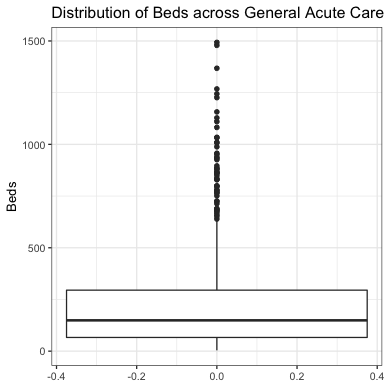

```r
hospitals_data %>%
  filter(STATUS == "OPEN" & TYPE == "GENERAL ACUTE CARE") %>%
  ggplot(aes(y = BEDS)) +
  geom_boxplot() +
  labs(title = "Distribution of Beds across General Acute Care Hospitals in the US that are Open", y = "Beds") +
  theme_bw()
```

> Note how we can title a boxplot very similarly to how we title a frequency plot. Both show distributions of values.

We can see from this plot that the quartile deviation is much smaller than the range in our dataset. This suggests that centered values are more concentrated than the extremes. State-aggregated COVID cases have a similar distribution:

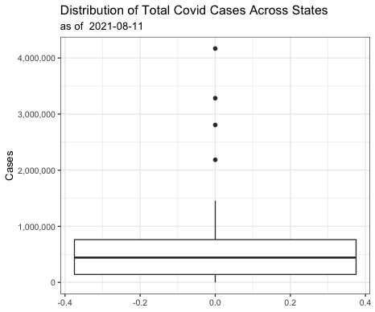

### Standard Deviation

*Standard deviation* (or SD) calculates the extent of concentration of values around the mean. A higher standard deviation indicates that values are more dispersed from the mean, and a lower standard deviation indicates that values are more concentrated around the mean.

| sd_value |
| --- |
| 208.2826 |

Note that the SD uses the mean as its measure of central tendency around which to disperse, and as such is most meaningful when the mean itself is meaningful, e.g. when the distribution is symmetrical around the mean.

### Your Turn: Measures of Dispersion in Your Own Dataset

#### Select one of the numeric variables on which you calculated a measure of central tendency above, and calculate the maximum value, the minimum value, and the range of values within that variable.

Be sure to filter your dataset to ensure that you are summarizing across similar observations.

```r
#Fill your code to calculate max here.

#Fill your code to calculate min here.

#Fill your code to calculate range here.
```

What question might this measure of dispersion help to address?

```r
Fill your response here.
```

Do the numbers surprise you? What insight can you draw from this calculation?

```r
Fill your response here.
```

#### Create a boxplot for one of the numeric variables on which you calculated a measure of central tendency above.

Be sure to filter your dataset to ensure that you are plotting across similar observations.

```r
#Fill your plot here. Be sure to add a title and labels to your plot.
```

What question might this measure of dispersion help to address?

```r
Fill your response here.
```

What insight can you draw from the plot you created?

```r
Fill your response here.
```

### Calculate the standard deviation for one of the numeric variables on which you calculated a measure of central tendency above.

Be sure to filter your dataset to ensure that you are summarizing across similar observations.

```r
#Fill your code here.
```

What question might this measure of dispersion help to address?

```r
Fill your response here.
```

What insight can you draw from this calculation?

```r
Fill your response here.
```

### Reflect

Now that you have a sense of the dispersion of some of the values in your data, why do you believe the values are as concentrated or dispersed as they are? What do the measures of dispersion you calculated say about social, political, or economic life in the area the data is representing? You may need to do some research to answer this question. For instance, noting the dispersion of beds in the hospitals data, I may do a Web search for “Why do some hospitals in the US have more beds than others?” and find [this](https://www.nytimes.com/interactive/2020/03/17/upshot/hospital-bed-shortages-coronavirus.html) article. Be sure to assess the reputability of your source and cite it in your response below.

```r
Fill your response here.
```

## Grouped Quantitative Insights

Like we learned in regards to co-variation, some of the most interesting information we can gain from our data is how values change depending on where in the data we are looking.

### Boxplots

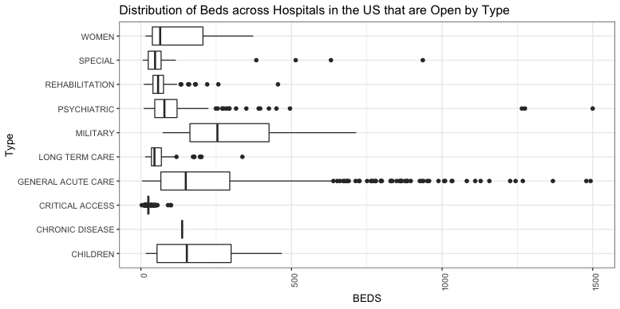

```r
hospitals_data %>%
  filter(STATUS == "OPEN") %>%
  ggplot(aes(x = TYPE, y = BEDS)) +
  geom_boxplot() +
  labs(title = "Distribution of Beds across Hospitals in the US that are Open by Type", x = "Type", Y = "Beds") +
  theme_bw() +
  theme(axis.text.x = element_text(angle = 90, hjust=1)) + # Changes x-axis tick labels 90 degrees
  coord_flip() # Flips the x and y axis to make the data easier to read and compare
```

Note that by default, the plots will be ordered alphabetically by your grouping variable, which isn’t usually what you want – you’d much rather see trends, no? The `reorder()` function lets you choose a value by which to organize instead. It takes three values: the grouping variable, the variable to sort by (applied within each group), and an optional function to apply to the sorting variable before reordering. Here, we might want to sort by median BED count for each hospital TYPE. It’s easiest to show you an example:

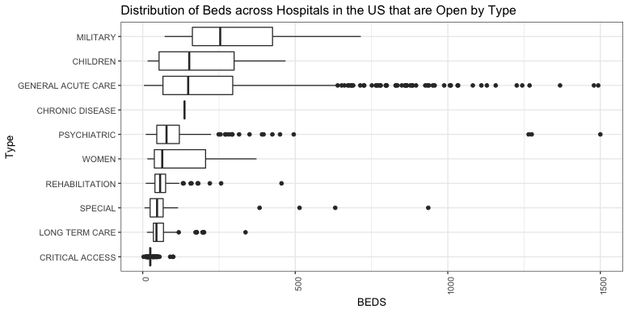

```r
hospitals_data %>%
  filter(STATUS == "OPEN") %>%
  ggplot(aes(x = fct_reorder(TYPE,   # group by TYPE
                             BEDS,   # sort by BEDS...
                             .fun = median,    # or rather, the median BEDS...
                             na.rm = TRUE),    # after removing NA values
             y = BEDS)) +
  geom_boxplot() +
  labs(title = "Distribution of Beds across Hospitals in the US that are Open by Type", x = "Type", Y = "Beds") +
  theme_bw() +
  theme(axis.text.x = element_text(angle = 90, hjust=1)) + # Changes x-axis tick labels 90 degrees
  coord_flip() # Flips the x and y axis to make the data easier to read and compare
```

NB: The `fct_reorder()` function comes with tidyverse as part of the forcats package; for more, run `?fct_reorder` at the console. For a generic R version, see `reorder()`.

We can also filter our data to similar values and the compare dispersions across another category.

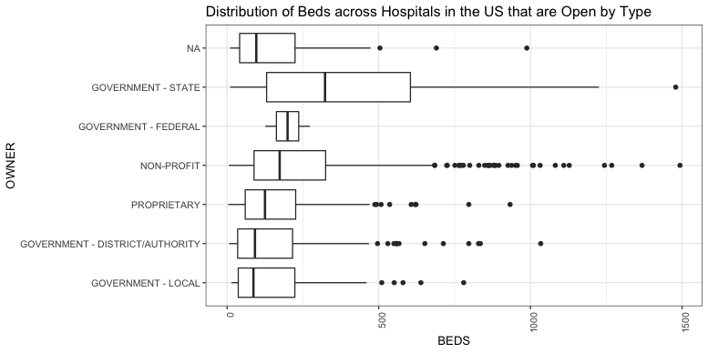

```r
#df %>% ggplot(aes(x = CATEGORICAL_VARIABLE, y = NUMERIC_VARIABLE)) + geom_boxplot()

hospitals_data %>%
  filter(STATUS == "OPEN" & TYPE == "GENERAL ACUTE CARE") %>%
  ggplot(aes(x = fct_reorder(OWNER, BEDS, median, na.rm=TRUE), y = BEDS)) +
  geom_boxplot() +
  labs(title = "Distribution of Beds across Hospitals in the US that are Open by Type", x = "OWNER", Y = "Beds") +
  theme_bw() +
  theme(axis.text.x = element_text(angle = 90, hjust=1)) + #Changes x-axis tick labels 90 degrees
  coord_flip() #Flips the x and y axis to make the data easier to read and compare
```

We see above that there is a greater dispersion in the number of beds available at state hospitals and non-profit hospitals. We also see that, in local hospitals, the median is closer to the first quartile than in other plots, and there are a number of outliers, indicating that the data is going to be more right skewed than in other plots. Compare this to federal hospitals, where the median is more centered in the box (and there are few outliers). We are likely to see a less skewed distribution in this plot. Let’s confirm this.

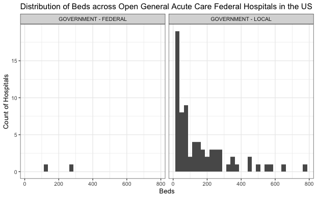

```r
hospitals_data %>%
  filter(STATUS == "OPEN" &
         TYPE == "GENERAL ACUTE CARE" &
         OWNER %in% c("GOVERNMENT - LOCAL", "GOVERNMENT - FEDERAL")) %>%
  ggplot(aes(x = BEDS)) +
  geom_histogram(binwidth = 25) +
  labs(title = "Distribution of Beds across Open General Acute Care Federal Hospitals in the US", x = "Beds", y = "Count of Hospitals") + # To add titles and labels
  theme_bw() +
  facet_grid(cols=vars(OWNER))
```

We can see above how the distribution in the Federal plot is more symmetrical than the distribution in the Local, confirming what we concluded above. However, we also see why: there are only two non-NA values in this combination of categories (Open, General Acute Care, and Federal). While boxplots are great at summarizing distribution within a sample, they don’t usually do such a great job of representing the relative sizes of samples.

### Create a grouped boxplot for your dataset below.

Be sure to filter your dataset to ensure that you are summarizing across similar observations **or** ensure that each group is made up of similar observations.

```r
#Fill your code here. Add a title and labels to your plot.
```

Summarize what you learn from the plot.

```r
Fill your response here.
```

How does the story that this grouped boxplot tells differ from the story told by the single boxplot you created above? Interpret why the story differs.

```r
Fill your response here.
```